# Advanced graphics with R_part 2

Sameh MAGDELDIN

December 27-29, 2016

> Points to be covered in this session

### 10. Heat map analysis

### 11. Bar plots

### 12. Stacked bar plot

### 13. Proportional stacked bar plot (100% stacked bar graph)

### 14. Scatter plot matrix [pairwise comparison of bivariate and multivariate data]

> Heat map analysis is mainly used to present a large set of data in color. This kind of plot can not be produced by other method.

### suppose u have a data of 500x 500 how should you show them. Heat map

> required packages in this tutorial

```r
library(ggplot2)
library(reshape2)
library(RColorBrewer)
library(gplots)
library(plyr)
library(dplyr)
library(car)
library(GGally)
```

## 10. Heat map analysis

> Heat map analysis is mainly used to present a large set of data in color. This kind of plot can not be produced by other method.

### 2 things u need to think about when doing heatmap

> turning you data into matrix log the data if there is much variability between reads

```r
head(iris)
```

```
##   Sepal.Length Sepal.Width Petal.Length Petal.Width Species
## 1          5.1         3.5          1.4         0.2  setosa
## 2          4.9         3.0          1.4         0.2  setosa
## 3          4.7         3.2          1.3         0.2  setosa
## 4          4.6         3.1          1.5         0.2  setosa
## 5          5.0         3.6          1.4         0.2  setosa
## 6          5.4         3.9          1.7         0.4  setosa
```

### i need to remove the last column (species). I’ll do that using select code in plyr and dplyr packages

```r
data <- select(iris,-Species)# - means 'make a new data called 'data' from iris dataset without species column
```

```r
head(data)
```

```
##   Sepal.Length Sepal.Width Petal.Length Petal.Width
## 1          5.1         3.5          1.4         0.2
## 2          4.9         3.0          1.4         0.2
## 3          4.7         3.2          1.3         0.2
## 4          4.6         3.1          1.5         0.2
## 5          5.0         3.6          1.4         0.2
## 6          5.4         3.9          1.7         0.4
```

### check what kind of data i have

```r
class(data)# tells u what class of data ; hereit is data.frame
```

```
## [1] "data.frame"
```

### Turn it into matrix

```r
data_matrix <- as.matrix(data)
```

### I will generate the heat map

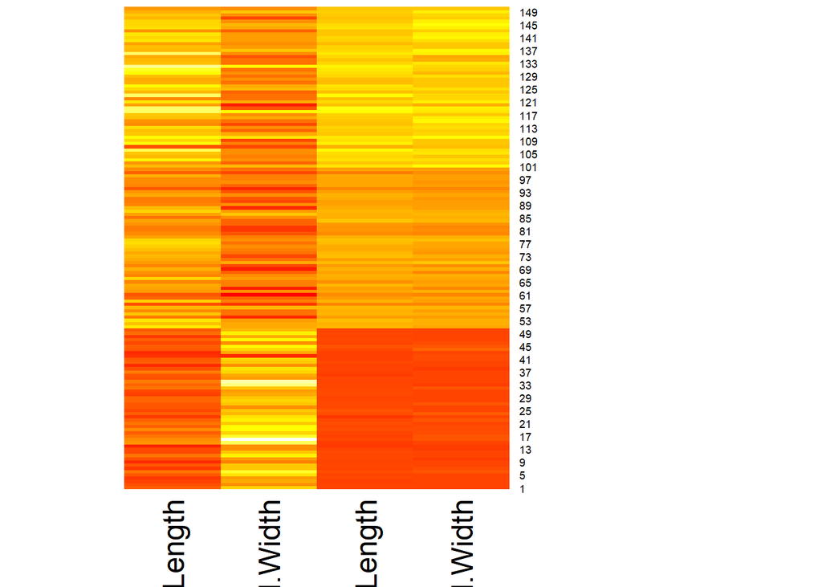

```r
data_heatmap <-heatmap(data_matrix, Rowv=NA, Colv=NA, col =heat.colors(256), scale="column", margins=c(5,10))
```

### the color increase in intensity with value increase.

### Lets do more sophisticated heatmap. I will use another package called gplots, also we need RColorBrewer package to play with the colors

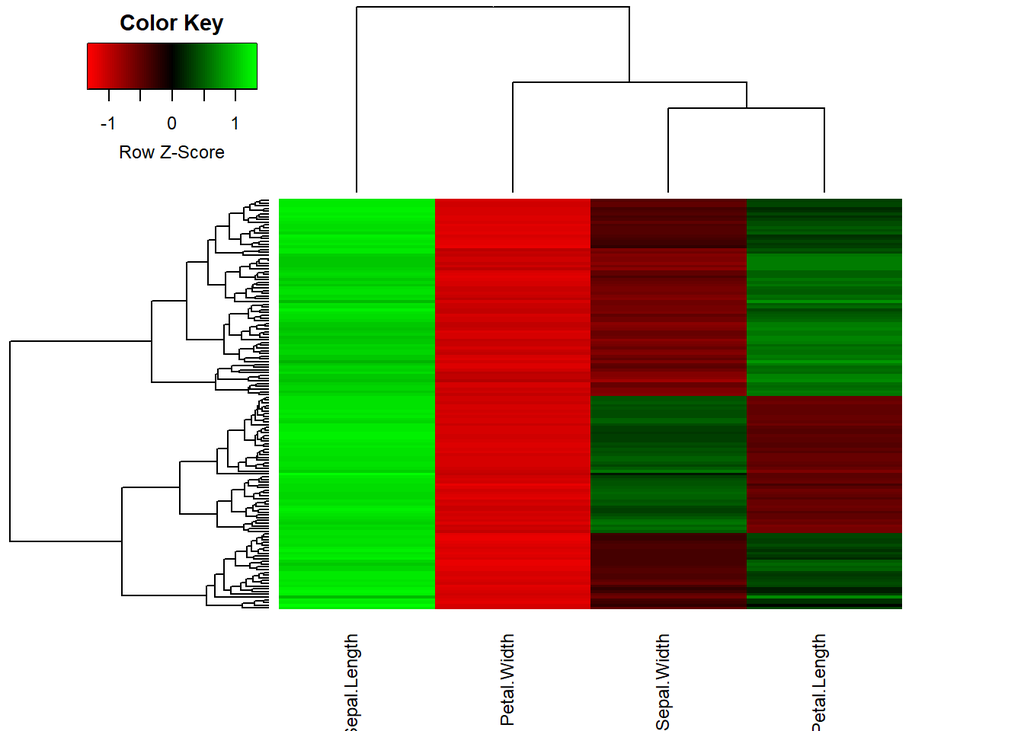

```r
heatmap.2(data_matrix, col=redgreen(75), scale="row", key=T, keysize=1.5,density.info="none", trace="none",cexCol=0.9, labRow=NA)
```

```r
head(data_matrix,n=5)# highest reads in septal length and lowest in petal width
```

```
##      Sepal.Length Sepal.Width Petal.Length Petal.Width
## [1,]          5.1         3.5          1.4         0.2
## [2,]          4.9         3.0          1.4         0.2
## [3,]          4.7         3.2          1.3         0.2
## [4,]          4.6         3.1          1.5         0.2
## [5,]          5.0         3.6          1.4         0.2
```

### its important to tell R if you want to score based on row or column. color of each pixel is compared to row or column?. in general u need to do it by row “as each row is an observation”

### lets see if we changed scoring to col

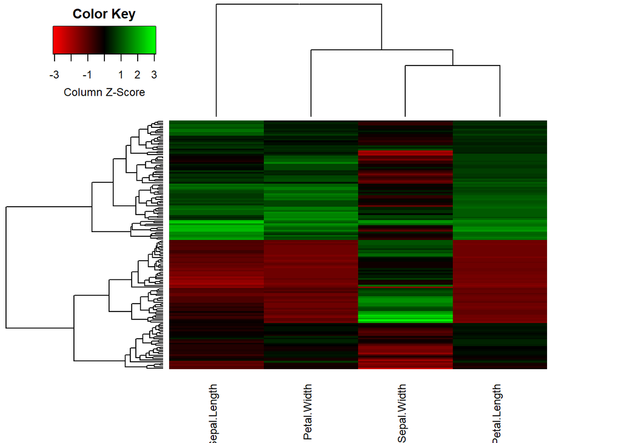

```r
heatmap.2(data_matrix, col=redgreen(75), scale="col", key=T, keysize=1.5,density.info="none", trace="none",cexCol=0.9, labRow=NA)
```

### additional information could be added (histogram) in the key, lets see how

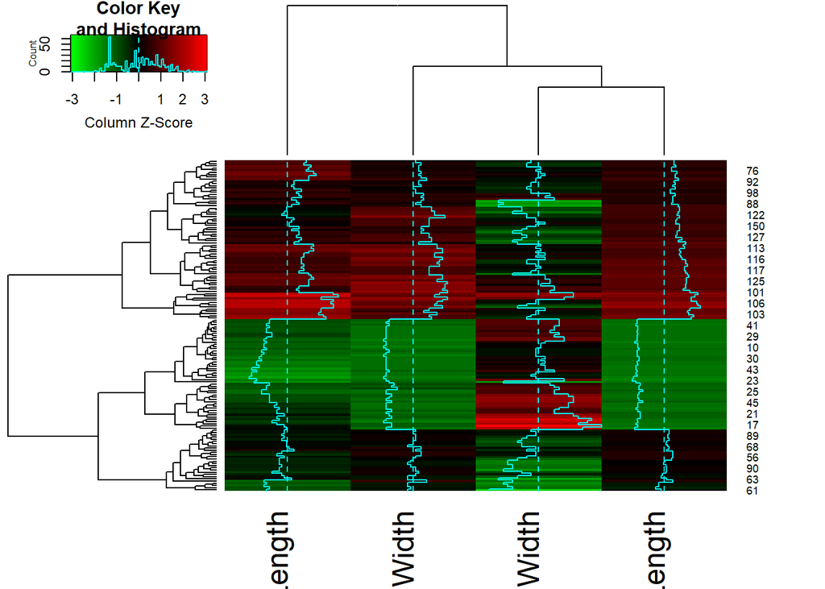

```r
heatmap.2(data_matrix,col=greenred(75),scale="col")
```

### note that here the color is reversed, u can always check the key

> Professional plotting tip

### Heat map generate a big plot that might contain observations with no significant changes. we can refine the matrix by telling R to plot most variable observations “in most cases most significant”. in many cases this might plot more clear “less crowded” images.

```r
head(data_matrix)
```

```
##      Sepal.Length Sepal.Width Petal.Length Petal.Width
## [1,]          5.1         3.5          1.4         0.2
## [2,]          4.9         3.0          1.4         0.2
## [3,]          4.7         3.2          1.3         0.2
## [4,]          4.6         3.1          1.5         0.2
## [5,]          5.0         3.6          1.4         0.2
## [6,]          5.4         3.9          1.7         0.4
```

```r
str(data_matrix)# note that data matrix is 150 obs
```

```
##  num [1:150, 1:4] 5.1 4.9 4.7 4.6 5 5.4 4.6 5 4.4 4.9 ...
##  - attr(*, "dimnames")=List of 2
##   ..$ : NULL
##   ..$ : chr [1:4] "Sepal.Length" "Sepal.Width" "Petal.Length" "Petal.Width"
```

### now follow me

```r
var <- apply(data_matrix,1,var) #calculate variance in the data. require plyr and dplyr packages.
```

```r
mostvariable <- data_matrix[var>quantile(var,0.75),]# telling R to make a new matrix called most varibale by selecting row that is above 75Th percentile. This means top 25% [remember box plot explanation?]
```

```r
str(mostvariable)# R selected 38 observations from the original 150. smart:)
```

```
##  num [1:38, 1:4] 5.4 5.4 5.8 5.7 5.4 5.7 5.4 5.2 5.2 5.4 ...
##  - attr(*, "dimnames")=List of 2
##   ..$ : NULL
##   ..$ : chr [1:4] "Sepal.Length" "Sepal.Width" "Petal.Length" "Petal.Width"
```

### lets heatmap them

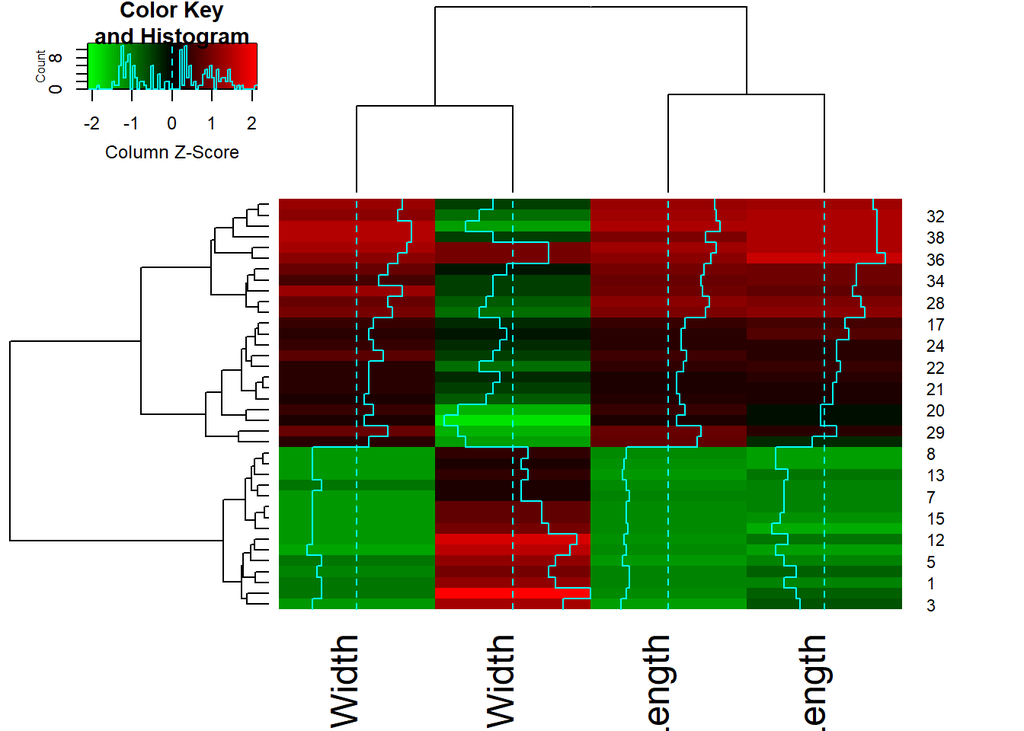

```r
heatmap.2(mostvariable,col=greenred(75),scale="col")
```

### I dont like the color, lets change it

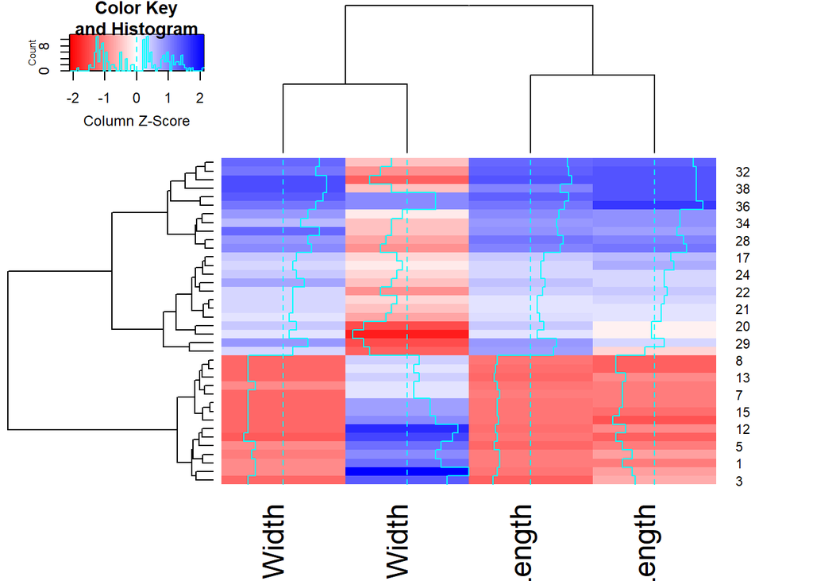

```r
heatmap.2(mostvariable,col=redblue(75),scale="col")
```

```r
#reset graphical device
dev.off()
```

### remember, the number after color [redblue(75)] is the palette percision. try 20 and 200 for example. it affects histogram (binwidth)

### you can change the text angle, change keysize,remove dendrogram,remove trace “indicator lines within pixels”, change text size for row and col by adding these extensions.

### try it by yourself

> heatmap.2(mostvariable,col=redblue(75),scale=“col”,srtCol=45,keysize=1,dendrogram=“none”, trace=“none”,cexRow=1.5,cexCol=1.5)

[figure not shown]

my graph

## 11. Bar plots

> When working with R , you need to think about your data arrangement before coding for graphics.

*** lets import iris dataset again***

```r
head(iris)
```

```
##   Sepal.Length Sepal.Width Petal.Length Petal.Width Species
## 1          5.1         3.5          1.4         0.2  setosa
## 2          4.9         3.0          1.4         0.2  setosa
## 3          4.7         3.2          1.3         0.2  setosa
## 4          4.6         3.1          1.5         0.2  setosa
## 5          5.0         3.6          1.4         0.2  setosa
## 6          5.4         3.9          1.7         0.4  setosa
```

*** we need to make another table includes the mean , SD, SEM for the data based on species. At first, i will use only Sepal.Length column***

*** i will use ddply function “check earlier topic about error bars in part 1”***

```r
barsummary_septal <- ddply(iris, c("Species"), summarise,mvalue = mean(Sepal.Length, na.rm=TRUE),medvalue=median(Sepal.Length, na.rm=TRUE), sd = sd(Sepal.Length, na.rm=TRUE),n = sum(!is.na(Sepal.Length)),se = sd/sqrt(n))
```

```r
barsummary_septal
```

```
##      Species mvalue medvalue        sd  n         se
## 1     setosa  5.006      5.0 0.3524897 50 0.04984957
## 2 versicolor  5.936      5.9 0.5161711 50 0.07299762
## 3  virginica  6.588      6.5 0.6358796 50 0.08992695
```

*Now , i can plot the graph*

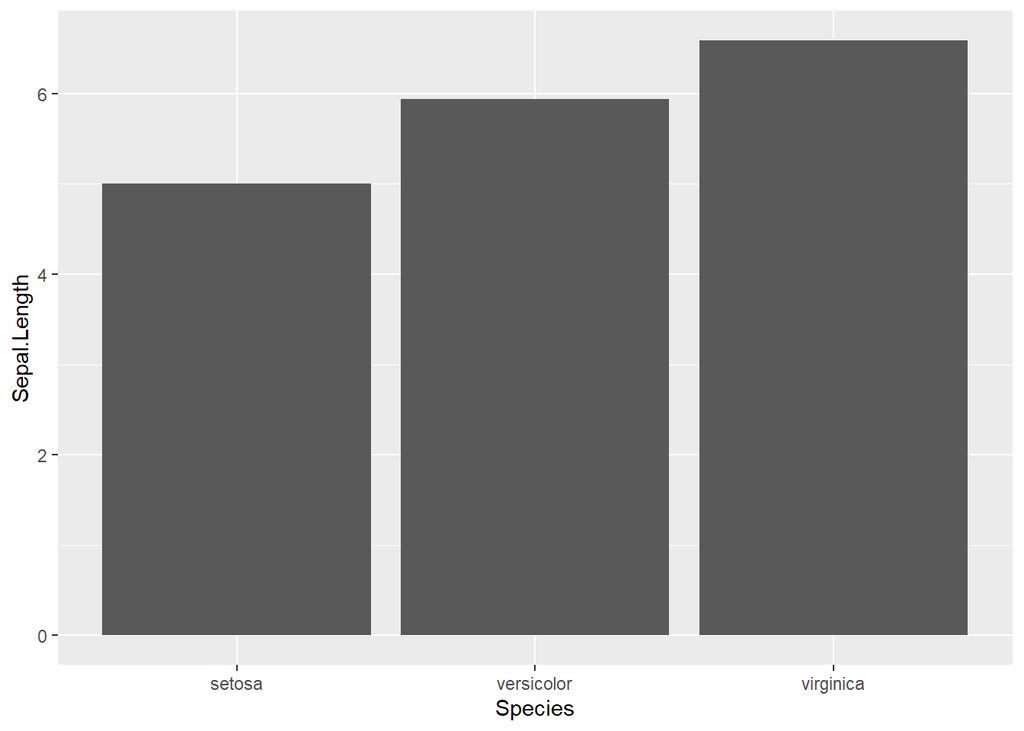

```r
ggplot(barsummary_septal, aes(x=Species, y=mvalue)) + geom_bar(stat="identity") + labs(x="Species", y="Sepal.Length")
```

*** Yes, its Ugly***

### In previous initial graph, i created a summary table for “spetal.length” that includes, mean, median, number of observation and standard error of mean. I will use the SD or SEM for plotting error bars later. but now , i want to resummarize the barsummary data to include all other flower columns.

###here is the steps

1. changing the format of the table to long using melt function (reshape 2 package) based on species

```r
melted <- melt(iris, id.vars=c("Species"))
```

###check the new table shape

```r
head(melted)
```

```
##   Species     variable value
## 1  setosa Sepal.Length   5.1
## 2  setosa Sepal.Length   4.9
## 3  setosa Sepal.Length   4.7
## 4  setosa Sepal.Length   4.6
## 5  setosa Sepal.Length   5.0
## 6  setosa Sepal.Length   5.4
```

```r
tail(melted)
```

```
##       Species    variable value
## 595 virginica Petal.Width   2.5
## 596 virginica Petal.Width   2.3
## 597 virginica Petal.Width   1.9
## 598 virginica Petal.Width   2.0
## 599 virginica Petal.Width   2.3
## 600 virginica Petal.Width   1.8
```

### 2. Now, i will resummarize the data based on *** species and variable***

```r
barsummary_all <- ddply(melted, c("Species","variable"), summarise,mvalue = mean(value, na.rm=TRUE),medvalue=median(value, na.rm=TRUE), sd = sd(value, na.rm=TRUE),n = sum(!is.na(value)),se = sd/sqrt(n))
```

###Now, we are ready

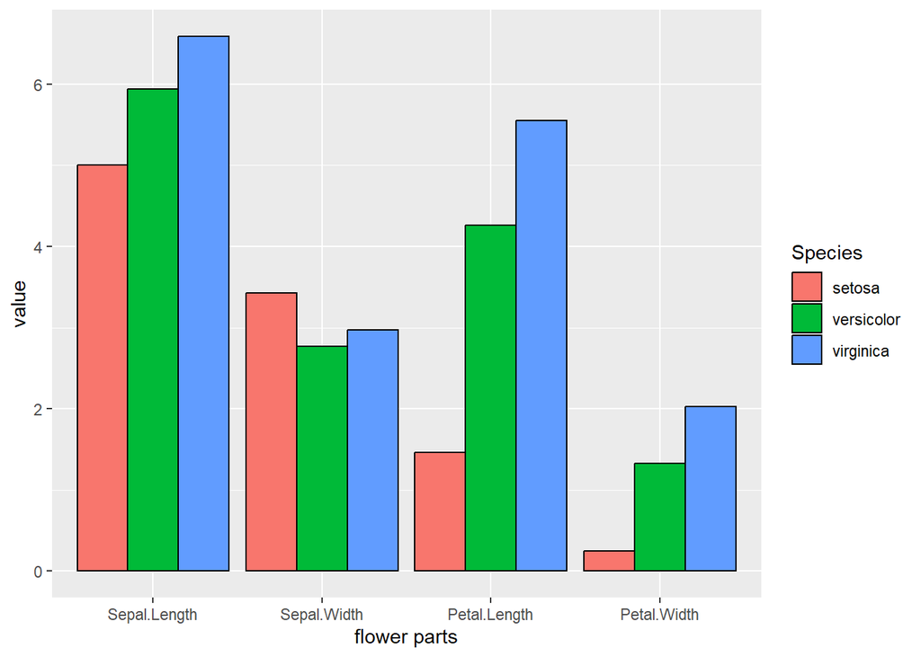

```r
ggplot(barsummary_all, aes(x=variable, y=mvalue,fill=Species)) + geom_bar(position="dodge",color="black",stat="identity") + labs(x="flower parts", y="value")
```

### more better,lets add the error bars “check error bar previously discussed”. I can use SD or SEM from the table. Here i will use SD.

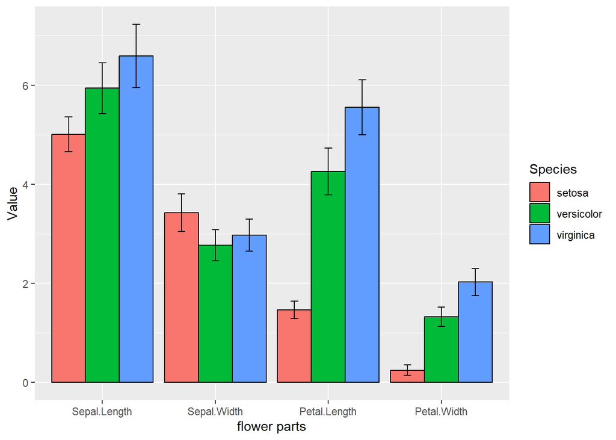

```r
ggplot(barsummary_all, aes(x=variable, y=mvalue,fill=Species)) + geom_bar(position="dodge",color="black",stat="identity") + labs(x="flower parts", y="Value")+geom_errorbar(aes(ymin=mvalue-sd,ymax=mvalue+sd),position=position_dodge(0.9), width=.2)
```